# Lecture Week 13: GLM

# 1 Overview

- Generalized linear models are useful when your response variable is not normally distributed.
- GLMs are often an alternative to transformations of data
- GLMs work by using linear predictors, a variance function, and a link function
- Linear predictors are what we have used before - they can be categorical or continuous
- The linear models we have used so far use the normal distribution for our variance function (hence meeting the assumptions previously discussed), but now we can pick different functions
  - Here we will look at the $Poisson(\lambda)$ and the $Binomial(n, p)$ distributions
- The link function is new - this takes the place of transformations, but instead of transforming the raw data (as before), it transforms the predictions made by the linear component

# 2 Setup

### 2.0.1 Libraries

```r
# libraries
library(tidyverse)
library(Sleuth3)
```

### 2.0.2 Data

```r
# data objects
elephant <- case2201
```

# 3 Lecture Outline

## 3.1 Poisson distribution

- The Poisson distribution is useful when the variable takes on discrete, positive, whole numbers
- This is often the count of something
  - Minimum bound is 0
  - Maximum bound is $+\infty$
- The Poisson is described by a single parameter $\lambda$
- Therefore, we would say that:

$$Y \sim Poisson(\lambda)$$

- Recall that a normal distribution is defined with two parameters: $N(\mu, \sigma)$, where $\mu$ is the average or expected value, and $\sigma$ is the spread of the data, but it is a fixed entity
- With a poisson, $\lambda$ described the expected value and the variance or noise around that value:

$$\lambda = E(Y) = Var(Y)$$

- So as the expected value increases, so does the variation

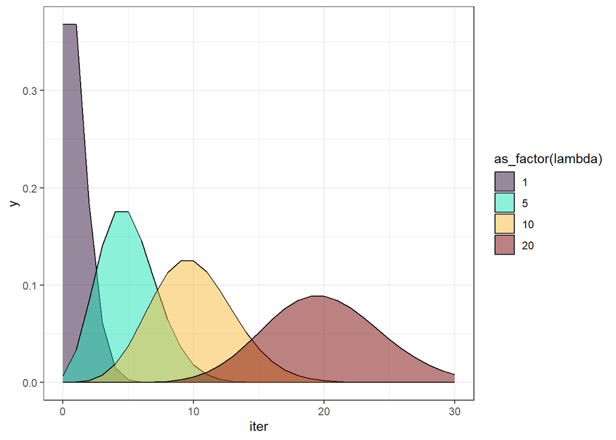

```r
pois_df <- expand_grid(iter = 0:30,
                       lambda = c(1, 5, 10, 20)) |>
  mutate(y = dpois(iter, lambda))

ggplot(pois_df,
       aes(y = y,
           x = iter,
           fill = as_factor(lambda))) +
  geom_density(stat = "identity",
               alpha = 0.5) +
  scale_fill_viridis_d(option = "turbo") +
  theme_bw()
```

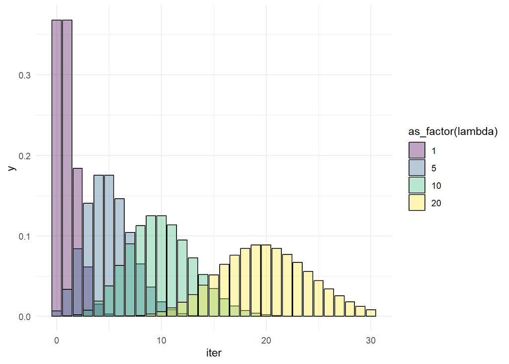

```r
ggplot(pois_df,
       aes(y = y,
           x = iter,
           fill = as_factor(lambda))) +
  geom_histogram(stat = "identity",
               alpha = 0.35,
               position = "identity",
               color = "black") +
  scale_fill_viridis_d() +
  theme_minimal()
```

## 3.2 Elephant Data

- `case2201` is observational data on the number of mates that male elephants have and their age
- Male elephants are sexually mature at ~15 years old, but can rarely out compete older, larger males for access to females

```r
as_tibble(elephant)
```

```
# A tibble: 41 × 2
     Age Matings
   <int>   <int>
 1    27       0
 2    28       1
 3    28       1
 4    28       1
 5    28       3
 6    29       0
 7    29       0
 8    29       0
 9    29       2
10    29       2
# ℹ 31 more rows
```

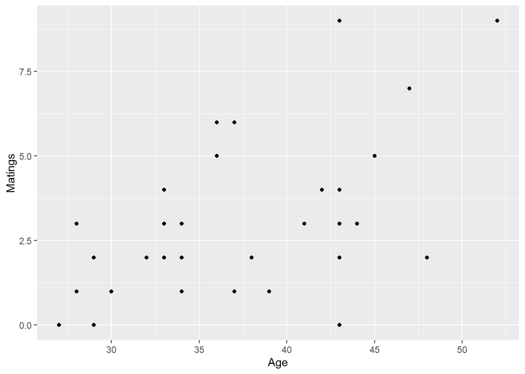

```r
ggplot(elephant,
       aes(x = Age,
           y = Matings)) +
  geom_point()
```

- This looks like a positive relationship, and we can put a linear regression line here:

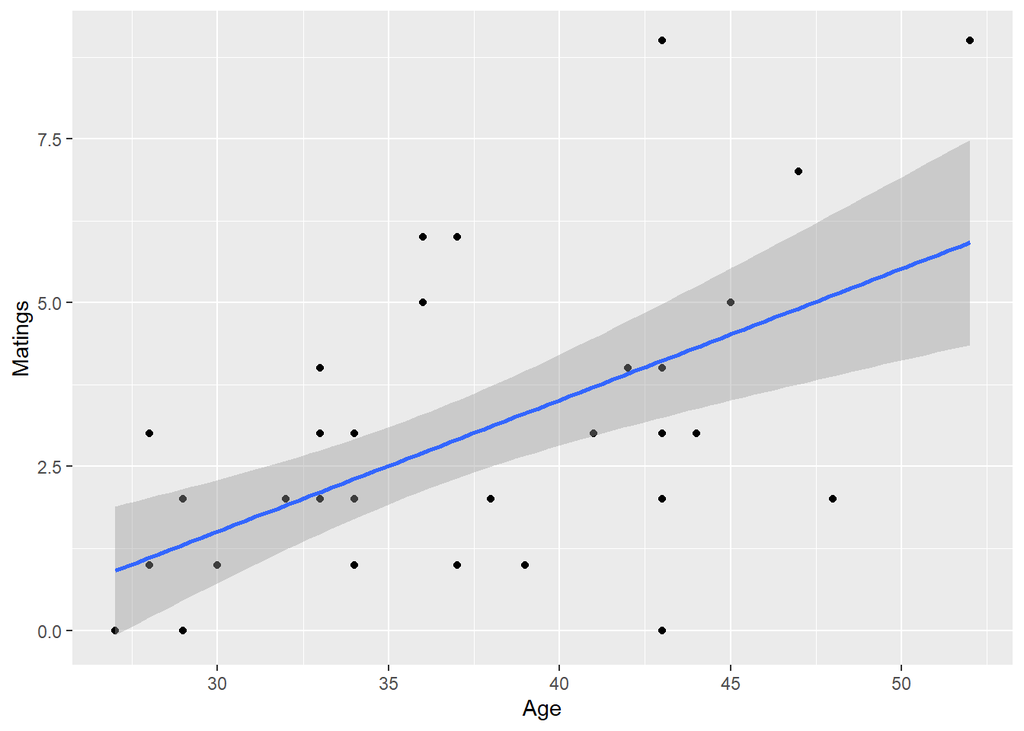

```r
ggplot(elephant,
       aes(x = Age,
           y = Matings)) +
  geom_point() +
  geom_smooth(method = "lm")
```

- Note that if we extended the line, it would quickly predict “negative” mates, which is not possible

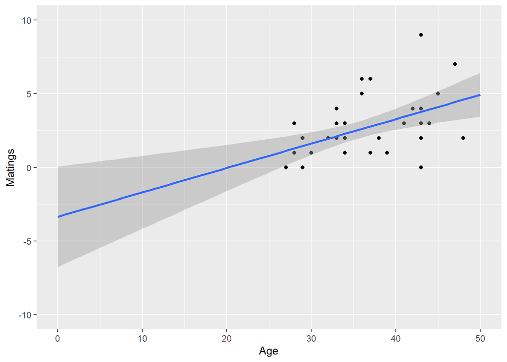

```r
ggplot(elephant,
       aes(x = Age,
           y = Matings)) +
  geom_point() +
  geom_smooth(method = "lm",
              fullrange = TRUE) +
  scale_x_continuous(limits = c(0, 50))+
  scale_y_continuous(limits = c(-10, 10))
```

## 3.3 Poisson Regression with `glm()`

- The `lm()` function produces linear models
- The `glm()` function produces generalized linear models
- The syntax is generally the same with a formula and a data argument
- What is added is a `family =` argument which allows you to designate other distribution families.
- We will set `family = poisson`
  - There is also a `link =` argument inside of the family call
  - The default link for Poisson is `log`
  - Other links exist, but we will just stick with the defaults here
  - Note that the back-transformation for a `log()` value is to exponentiate the value; `exp()` in R
    - i.e., `log(4)` = 1.386294
    - `exp(1.386296)` = 3.999999 = 4

```r
ele_glm <- glm(Matings ~ Age,
               data = elephant,
               family = poisson(link = "log"))
summary(ele_glm)
```

```
Call:
glm(formula = Matings ~ Age, family = poisson(link = "log"),
    data = elephant)

Coefficients:
            Estimate Std. Error z value Pr(>|z|)
(Intercept) -1.58201    0.54462  -2.905  0.00368 **
Age          0.06869    0.01375   4.997 5.81e-07 ***
---
Signif. codes:  0 '***' 0.001 '**' 0.01 '*' 0.05 '.' 0.1 ' ' 1

(Dispersion parameter for poisson family taken to be 1)

    Null deviance: 75.372  on 40  degrees of freedom
Residual deviance: 51.012  on 39  degrees of freedom
AIC: 156.46

Number of Fisher Scoring iterations: 5
```

- Before we go into the model estimates, we first need to ask if Poisson is a reasonable fit for this data.
- A Poisson distributed variable should have its mean and variance be approximately equal.
- We can check this by looking at the ratio of residual deviance to the degrees of freedom
  - A perfect ratio would be 1
  - General rule of thumb is anything > 2 could be problematic

```r
51/39
```

```
[1] 1.307692
```

- This model looks good

## 3.5 Working with the model

```r
summary(ele_glm)
```

```
Call:
glm(formula = Matings ~ Age, family = poisson(link = "log"),
    data = elephant)

Coefficients:
            Estimate Std. Error z value Pr(>|z|)
(Intercept) -1.58201    0.54462  -2.905  0.00368 **
Age          0.06869    0.01375   4.997 5.81e-07 ***
---
Signif. codes:  0 '***' 0.001 '**' 0.01 '*' 0.05 '.' 0.1 ' ' 1

(Dispersion parameter for poisson family taken to be 1)

    Null deviance: 75.372  on 40  degrees of freedom
Residual deviance: 51.012  on 39  degrees of freedom
AIC: 156.46

Number of Fisher Scoring iterations: 5
```

- We have coefficient estimates for our intercept and $\beta_1$ So we can write out our equation
- An important note though, is that the equation will predict the number of mates on the *transformed* scale
  - With every 1-year increase in age, a male will have an increase of 0.069 mates *on the log-scale*
  - `exp(0.069)` = 1.07. This is **not** an increase of 1.07 mates. It’s an increase of 7% more mates than the year before
  - This is a percentage change, not an absolute change
- It is usually easier to estimate the response on the log-scale, and then back-transform our result to get back on the same scale as the original data
  - i.e., the number of mates

$$Log(Mates) = \beta_0 + \beta_1 * Age$$

- Let’s fill out the equation, and estimate the number of mates for a 40 year old male

$$Log(Mates) = -1.58 + 0.069 * 40$$

```r
# log-scale
-1.58 + 0.069*40
```

```
[1] 1.18
```

- To put this on the “real” scale, we need to exponentiate

$$e^{1.18}$$

```r
exp(1.18)
```

```
[1] 3.254374
```

```r
# "real" scale
```

- A 40 year old male elephant will have had an average of **3.25 mates**

**Prediction with GLM’s**

- It is possible to use `predict()` with `newdata` for GLM models
- There are a few extra steps to accurately estimate the interval (either confidence or prediction)
- I’m not going to go into the details here, but there are a number of resources online which explain it in detail
- For the home work problems in this class, I will only ask you to calculate the estimated response for a given value of a predictor variable one at a time
  - i.e., like we did above
  - Plug in one x-value to the equation
  - calculate the estimate on the log-scale
  - Exponentiate to get the estimate back on the same scale as the data